# Spectral analysis and observation processing example

Gauthier Magnin

Last update: 2020-12-18

**/!\ OUTDATED /!\**

The example of analysis proposed in this document assumes the reader is familiar with the spectral analysis methodology. If not, the reader should read at least the first of the following two papers:

- Bosson-Rieutort D, de Gaudemaris R, Bicout DJ (2018). The spectrosome of occupational health problems. *PLoS ONE* 13(1): e0190196. https://doi.org/10.1371/journal.pone.0190196
- Bosson-Rieutort D, Sarazin P, Bicout DJ, Ho V, Lavoué J (2020). Occupational Co-exposures to Multiple Chemical Agents from Workplace Measurements by the US Occupational Safety and Health Administration. *Annals of Work Exposures and Health*, Volume 64, Issue 4, May 2020, Pages 402–415. https://doi.org/10.1093/annweh/wxaa008.

For more details about the functions used throughout this example (use of the parameters, other parameters and default values), it is recommended to consult the help pages of the functions along with it. Help pages can be access using the `help` function in your console or by referring to the List of datasets, functions, classes and methods section of this document.

# 1. Preparation of data and spectral analysis

## 1.1. Loading package and look at the example data

```r
# Loading package
library(oedb.analysis.tools)
```

Here are illustrative data from an occupational exposure database:

```r
oedb_sample
```

| ID | YEAR | CODE | NAME | SAMPLE.ID | ACTIVITY | JOB.TITLE | JOB.TASK | CONCENTRATION |
| --- | --- | --- | --- | --- | --- | --- | --- | --- |
| 2016-BX-3026 | 2016 | 1603 | Méthacrylate de butyle | 22 | 2825Z | 44121004 | A5440 | 0.5000 |
| 2016-BX-3026 | 2016 | 163 | Méthacrylate de méthyle | 36 | 2825Z | 44121004 | A5440 | 2.0000 |
| 2016-BX-3026 | 2016 | 49 | Ethanol | 31 | 2825Z | 44121004 | A5440 | 0.5000 |
| 2013-BX-5012 | 2013 | 57 | Formaldéhyde | 18 | 2825Z | 44132024 | A5310 | 0.0070 |
| 2016-BX-3026 | 2016 | 1603 | Méthacrylate de butyle | 102 | 2825Z | 44121004 | A5440 | 0.5000 |
| 2016-BX-3026 | 2016 | 163 | Méthacrylate de méthyle | 88 | 2825Z | 44121004 | A5440 | 2.0000 |
| 2016-BX-3026 | 2016 | 49 | Ethanol | 104 | 2825Z | 44121004 | A5440 | 0.5000 |
| 2016-BX-3026 | 2016 | 1603 | Méthacrylate de butyle | 84 | 2825Z | 44121004 | A5440 | 0.5000 |
| 2016-BX-3026 | 2016 | 163 | Méthacrylate de méthyle | 94 | 2825Z | 44121004 | A5440 | 2.0000 |
| 2016-BX-3026 | 2016 | 49 | Ethanol | 95 | 2825Z | 44121004 | A5440 | 0.5000 |

[output cut: 121 more lines]

In this database, samples for which substances sought were not found have been removed; a filter was carried out on a particular work sector and a specific subset of data was extracted. Each line corresponds to a sample.

Here is the help page describing these data (accessible using `help(oedb_sample)`):

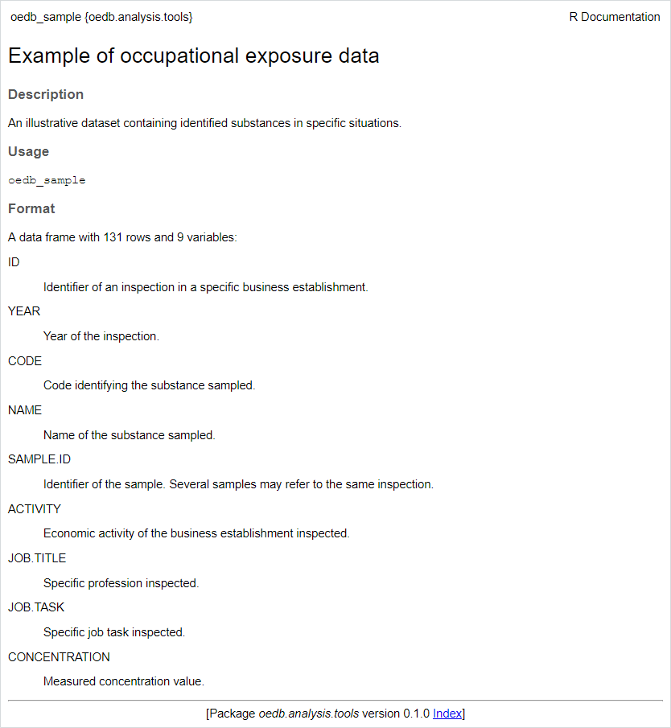

## 1.2. Construction of an observation structure from sampling data

### 1.2.1. Definition of the structure

Defining a set of work situations…

```r
work_situations <- data.frame(WS.ID = c(1, 2, 2, 3, 3),
                              JOB.TITLE = c(44121004, 44142001, 44132032, 44132019, 44132030),
                              JOB.TASK = c("A5440", "A6410", "A5110", "A5260", "A5240"),
                              stringsAsFactors = FALSE)
work_situations
```

| WS.ID | JOB.TITLE | JOB.TASK |
| --- | --- | --- |
| 1 | 44121004 | A5440 |
| 2 | 44142001 | A6410 |
| 2 | 44132032 | A5110 |
| 3 | 44132019 | A5260 |
| 3 | 44132030 | A5240 |

These are work situations the user could identify beforehand. **The data frame must have a *WS.ID* column to identify the different work situations described.** The other columns correspond to the variables to use to describe a work situation and have the same names as the variables in the database used.

For this fictitious example, the variables named `JOB.TITLE` and `JOB.TASK` are used and random combinations were picked. Several couples with the same `WS.ID` are considered to correspond to the same work situation. Three work situations are described. The first one has one combination of the two variables. The second has two combinations which are considered as works with similar conditions. The last one is formed in the same way as the second one.

Defining the set of variables used to search for situations that have not been described in the previous data frame…

```r
variable_names <- c("JOB.TITLE", "JOB.TASK")
```

Each combination of these variables will be considered as a new work situation.

Defining the set of information to be kept in the observation structure…

```r
additional <- c("NAME", "ACTIVITY", "JOB.TITLE", "JOB.TASK", "SAMPLE.ID")
```

This is additional information which is not useful for spectral analysis but which allows to find a posteriori the context associated with the observations.

### 1.2.2. Construction of the observations

There are 4 possibilities here:

1. A single observation per inspection in an establisment…

```r
observations1 <- make_observations(oedb_sample,
                                   by = "ID",
                                   additional = c("CODE", additional),
                                   unique_values = TRUE)

# Print the number of observations
cat(length(observations1), "observations.\n")
```

```
14 observations.
```

```r
# Print one observation to see what it looks like
observations1[14]
```

```
$`2018-NT-18042`
$`2018-NT-18042`$ID
[1] "2018-NT-18042"

$`2018-NT-18042`$CODE
[1] 3157 3350

$`2018-NT-18042`$NAME
[1] "Chrome VI et ses composés" "Fumées de soudage"

$`2018-NT-18042`$ACTIVITY
[1] "2825Z"

$`2018-NT-18042`$JOB.TITLE
[1] 44132015

$`2018-NT-18042`$JOB.TASK
[1] "A5210"

$`2018-NT-18042`$SAMPLE.ID
[1] 55 85
```

2. For one inspection, search of the work situations described previously…

```r
observations2 <- make_INRS_observations(oedb_sample,
                                        mode = 2,
                                        work_situations = work_situations,
                                        additional = additional,
                                        unique_values = TRUE)

# Print the number of observations
cat(length(observations2), "observations.\n")
```

```
3 observations.
```

```r
# Print one observation
observations2[[2]]
```

```
$CODE
[1]  252   87   19 3146  929 3156  930  497  402

$YEAR
[1] 2016

$ID
[1] "2016-NT-16064"

$NAME
[1] "Hydrocarbures aliphatiques et alicycliques"
[2] "Butanone"
[3] "Acétate de n-butyle"
[4] "Poussières inhalables"
[5] "Argent métallique"
[6] "Chrome (métal, composés de chrome inorganiques (II) et composés de chrome inorganiques (insolubles) (III))"
[7] "Cuivre"
[8] "Nickel"
[9] "Zinc"

$ACTIVITY
[1] "2825Z"

$JOB.TITLE
[1] 44142001 44132032

$JOB.TASK
[1] "A6410" "A5110"

$SAMPLE.ID
 [1] 106  29  17 117  91  26 105  57 126   5   6 115  30   7 109
```

3. For one inspection, as many work situations as different `JOB.TITLE`-`JOB.TASK` pairs…

```r
observations3 <- make_INRS_observations(oedb_sample,
                                        mode = 3,
                                        variable_names = variable_names,
                                        additional = additional,
                                        unique_values = TRUE)

# Print the number of observations
cat(length(observations3), "observations.\n")
```

```
16 observations.
```

```r
# Print one observation
observations3[[2]]
```

```
$CODE
[1] 57 77

$YEAR
[1] 2013

$ID
[1] "2013-BX-5012"

$NAME
[1] "Formaldéhyde" "Benzène"

$ACTIVITY
[1] "2825Z"

$JOB.TITLE
[1] 44132024

$JOB.TASK
[1] "A5310"

$SAMPLE.ID
[1] 18  1 21
```

4. Combination of points 2 and 3: search of the work situations described previously and one observation per situation not described (`JOB.TITLE`-`JOB.TASK` pair) concerning the remaining samples…

```r
observations4 <- make_INRS_observations(oedb_sample,
                                        mode = 1,
                                        work_situations = work_situations,
                                        variable_names = variable_names,
                                        additional = additional,
                                        unique_values = TRUE)

# Print the number of observations
cat(length(observations4), "observations.\n")
```

```
14 observations.
```

```r
# Print one observation
observations4[[2]]
```

```
$CODE
[1] 57 77

$YEAR
[1] 2013

$ID
[1] "2013-BX-5012"

$NAME
[1] "Formaldéhyde" "Benzène"

$ACTIVITY
[1] "2825Z"

$JOB.TITLE
[1] 44132024

$JOB.TASK
[1] "A5310"

$SAMPLE.ID
[1] 18  1 21
```

**Note that the function used to create the last three lists of observations need the dataset to contain 3 variables named *ID*, *YEAR* and *CODE* to be able to function.**

For the rest of the example, use of the last one…

```r
observations <- observations4
```

## 1.3. Set up the analysis

### 1.3.1. Association of each item to categories

Here is a data frame associating substances to one family of substances and one subfamily:

```r
substances_information
```

| CODE | NAME | FAMILY | SUBFAMILY | TOXICITY | LIMIT |
| --- | --- | --- | --- | --- | --- |
| 109 | Acide borique | ACIDES | Acides minéraux |  | 2.000 |
| 1154 | Acide bromhydrique | ACIDES | Acides minéraux |  | 10.000 |
| 3189 | Acide chloreux | ACIDES | Acides minéraux |  | NA |
| 31 | Acide chlorhydrique | ACIDES | Acides minéraux |  | 7.600 |
| 70 | Acide chromique | ACIDES | Acides minéraux |  | 1.000 |
| 34 | Acide cyanhydrique | ACIDES | Acides minéraux |  | 2.000 |
| 30 | Acide nitrique | ACIDES | Acides minéraux |  | 2.600 |
| 13 | Acide perborique, sel de sodium | ACIDES | Acides minéraux |  | NA |
| 41 | Acide phosphorique | ACIDES | Acides minéraux |  | 1.000 |
| 301 | Acide sulfamidique | ACIDES | Acides minéraux |  | NA |

[output cut: 990 more lines]

Classification of the substances from the observations according to their subfamily…

```r
# Search for separate substances
substances <- get_all_items(observations)
# Search for the subfamily associated to each substance
families <- substances_information$SUBFAMILY[match(substances, substances_information$CODE)]
# As a precaution, assignment of a specific value to substances for which no family has been found
families[is.na(families)] <- "Unknown"
# Search for the name associated to each substance
names <- substances_information$NAME[match(substances, substances_information$CODE)]

# Print the number of separate substances
cat(length(substances), "substances.")
```

```
25 substances.
```

```r
# Print the codes of all substances found in the observations
substances
```

```
 [1]   19   25   27   49   57   71   77   87  148  163  192  252  328  402  497  929  930  931 1603
[20] 3146 3156 3157 3180 3345 3350
```

```r
# Print the number of separate families
cat(length(unique(families)), "families.")
```

```
17 families.
```

```r
# Print names of all families of substances found in the observations
unique(families)
```

```
 [1] "Esters"                                       "Cétones"
 [3] "Hydrocarbures aromatiques"                    "Alcools"
 [5] "Aldéhydes"                                    "Aluminium"
 [7] "Monomères"                                    "Hydrocarbures aliphatiques et cycloaliph"
 [9] "Ethers de glycol dérivés du propylène glycol" "Zinc"
[11] "Nickel"                                       "Argent"
[13] "Cuivre"                                       "Fer"
[15] "Poussières inhalables"                        "Chrome"
[17] "Manganese"
```

Creation of a table associating each substance with its name and some categories…

```r
items <- data.frame(item = substances,
                    name = names,
                    family = families)
items
```

| item | name | family |
| --- | --- | --- |
| 19 | Acétate de n-butyle | Esters |
| 25 | Acétone | Cétones |
| 27 | Toluène | Hydrocarbures aromatiques |
| 49 | Ethanol | Alcools |
| 57 | Formaldéhyde | Aldéhydes |
| 71 | Aluminium | Aluminium |
| 77 | Benzène | Hydrocarbures aromatiques |
| 87 | Butanone | Cétones |
| 148 | 4,4'-Diisocyanate de diphénylméthane | Monomères |
| 163 | Méthacrylate de méthyle | Esters |

[output cut: 15 more lines]

The column corresponding to the substance codes must be named **item**. The one corresponding to the substance names (which is optional) must be named **name**. The other names (for categories, which are also optional) are free.

Creation here of a *family* category corresponding to the subfamily associated with each substance.

Add other variables to the data frame to associate additional categories.

### 1.3.2. Instanciation of the object in charge of the analysis

Use of the default values to create a spectral analyzer (see the help manual of the function `spectral.analyzer`)…

```r
sa_object <- spectral.analyzer(observations, items)
```

```
*** Step 1/10:  Enumeration of the observations per year... [00s]
*** Step 2/10:  Enumeration of the nodes and calculation of the number of occurrences... [00s]
*** Step 3/10:  Counting links between nodes... [00s]
*** Step 4/10:  Elaboration of links between nodes... [00s]
*** Step 5/10:  Mining for itemsets...
```

```
You chose a very low absolute support count of 1. You might run out of memory! Increase minimum support.
```

```
[00s]
*** Step 6/10:  Linking nodes to patterns... [00s]
*** Step 7/10:  Characterization of patterns per year... [00s]
*** Step 8/10:  Computation of pattern characteristics... [00s]
*** Step 9/10:  Counting links between patterns... [00s]
*** Step 10/10: Elaboration of links between patterns... [00s]
```

The execution time for each step is displayed in the form [01h 22m 05s].

The *warning* message appearing is generated by one package used (*arules*) which informs that the choice of a minimum frequency of 1 for the enumeration of the patterns risks requiring more memory than available in case where a lot of data is used and many patterns exist. That is not the case here.

### 1.3.3. The resulting object

Some information about the data and the results of the spectral analysis calculations…

```r
summary(sa_object)
```

```
$patterns
$patterns$main
        year frequency weight specificity
Min.    2011      1.00   1.00  0.03903595
1st Qu. 2014      1.00   1.00  0.50000000
Median  2015      1.50   2.00  0.77042604
Mean    2015      1.75   1.90  0.68512221
3rd Qu. 2016      2.00   2.25  1.00000000
Max.    2018      4.00   5.00  1.00000000

$patterns$order
```

| order | count |
| --- | --- |
| 1 | 6 |
| 2 | 5 |
| 3 | 4 |
| 4 | 1 |
| 5 | 3 |
| 9 | 1 |

```
$patterns$status
```

| status | count |
| --- | --- |
| Emergent | 15 |
| Persistent | 5 |

```
$count
observations        items   categories        nodes     patterns
          14           25            1           12           20
```

Let’s take a look at the structure of the object…

```r
# Try this on your console to see more than the following picture
View(sa_object)
```

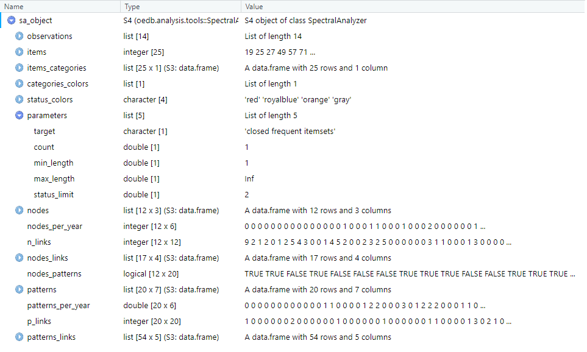

Fig. 1: View of the spectral analyzer object example.

Some of these attributes will be saved in output files (see the following sections).

To have a description of the attributes, type `help("SpectralAnalyzer")`. To know more about the types of attributes and methods variables, see *Types_of_attributes_and_methods.pdf* in the *doc* directory.

## 1.4. Saving the first results

Let’s create a directory for the outputs…

```r
directory <- "./output/"
dir.create(directory)
```

Saving the object…

```r
saveRDS(sa_object, paste0(directory, "spectral_analyzer_object.RDS"))
```

Take a look at the nodes and the patterns…

```r
sa_object["nodes"]
```

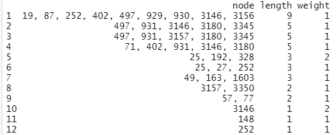

```r
sa_object["patterns"]
```

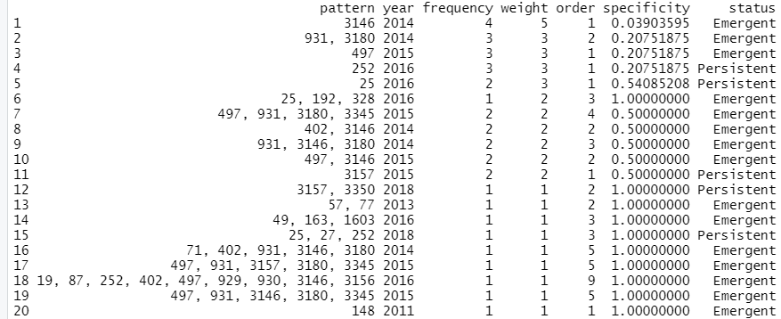

Saving the nodes and the patterns in CSV files…

```r
# Saving the nodes
save_characteristics(sa_object, sa_object["nodes"],
                     file = paste0(directory, "sao.nodes.csv"), row.names = FALSE)
# Saving the patterns
save_characteristics(sa_object, sa_object["patterns"],
                     file = paste0(directory, "sao.patterns.csv"), row.names = FALSE)
```

# 2. Working with nodes

## 2.1. Node visualization

```r
# Let's organize it a little bit more
directory <- "./output/spec_nodes/"
dir.create(directory)
```

Creation of the spectrosome of the nodes…

```r
spectrosome <- spectrosome_chart(sa_object, sa_object["nodes"],
                                 path = directory,
                                 name = "spectrosome_of_nodes.png",
                                 title = "Network of nodes")
```

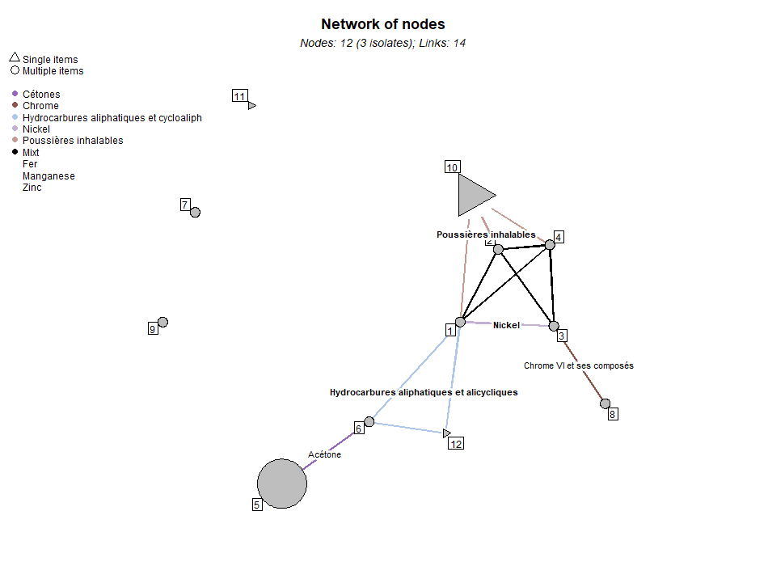

Fig. 2: Spectrosome of the nodes.

Saving vertex characteristics in a CSV file…

```r
save_characteristics(sa_object, spectrosome[["vertices"]],
                     file = paste0(directory, "spectrosome_of_nodes-vertices.csv"),
                     row.names = FALSE)

spectrosome[["vertices"]]
```

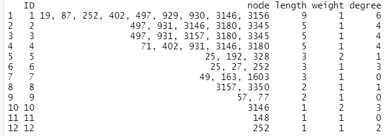

The vertices of this spectrosome are actually the nodes already saved before as *sao.nodes.csv* in section 1.4., but the new data frame also lists the identifiers of the vertices in the graph as well as their degrees (i.e. the number of adjacent vertices).

Saving edges characteristics as well…

```r
write.csv2(spectrosome[["edges"]],
           file = paste0(directory, "spectrosome_of_nodes-edges.csv"),
           row.names = FALSE)

spectrosome[["edges"]]
```

| ID | endpoint.1 | endpoint.2 | items | weight |
| --- | --- | --- | --- | --- |
| 1 | 1 | 2 | 497/3146 | 2 |
| 2 | 1 | 3 | 497 | 1 |
| 3 | 1 | 4 | 402/3146 | 2 |
| 4 | 1 | 6 | 252 | 1 |
| 5 | 1 | 10 | 3146 | 1 |
| 6 | 1 | 12 | 252 | 1 |
| 7 | 2 | 3 | 497/931/3180/3345 | 4 |
| 8 | 2 | 4 | 931/3146/3180 | 3 |
| 9 | 2 | 10 | 3146 | 1 |
| 10 | 3 | 4 | 931/3180 | 2 |

[output cut: 7 more lines]

## 2.2. Extraction of a cluster of nodes

Extraction of the node cluster relating to the item *3146*…

```r
item <- 3146
cluster <- cluster_chart(sa_object, sa_object["nodes"], item,
                         path = directory,
                         name = paste0("node_cluster_of_", item, ".png"),
                         title = paste("Network cluster of", item))
```

**Note that no graphic is created and *cluster* is *NULL* if none or only one node contains the desired substance (which is here the substance having the code *3146*).**

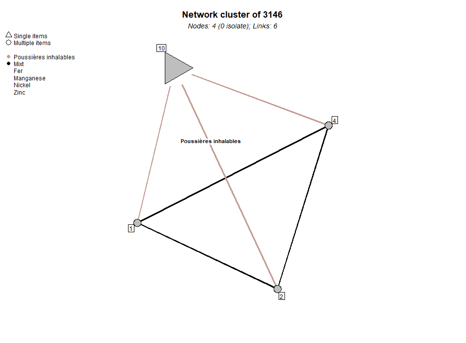

Fig. 3: Node cluster of 3146.

Saving vertex characteristics in a CSV file…

```r
save_characteristics(sa_object, cluster[["vertices"]],
                     file = paste0(directory, "node_cluster_of_", item, "-vertices.csv"),
                     row.names = FALSE)

cluster[["vertices"]]
```

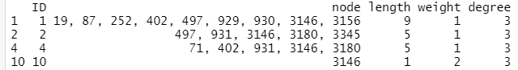

Saving edges characteristics as well…

```r
write.csv2(cluster[["edges"]],
           file = paste0(directory, "node_cluster_of_", item, "-edges.csv"),
           row.names = FALSE)

cluster[["edges"]]
```

|  | ID | endpoint.1 | endpoint.2 | items | weight |
| --- | --- | --- | --- | --- | --- |
| 1 | 1 | 1 | 2 | 497/3146 | 2 |
| 3 | 2 | 1 | 4 | 402/3146 | 2 |
| 5 | 3 | 1 | 10 | 3146 | 1 |
| 8 | 4 | 2 | 4 | 931/3146/3180 | 3 |
| 9 | 5 | 2 | 10 | 3146 | 1 |
| 12 | 6 | 4 | 10 | 3146 | 1 |

# 3. Working with patterns

## 3.1. Pattern visualizations

```r
directory <- "./output/spec_patterns/"
dir.create(directory)
```

### 3.1.1. Pattern itemsets

Representation of the patterns as itemsets…

```r
p_chart <- itemset_chart(sa_object, sa_object["patterns"],
                         n.cutoff = 20,
                         c.cutoff = 17,
                         path = directory,
                         name = "pattern_itemsets.pdf",
                         title = "Pattern itemsets")
```

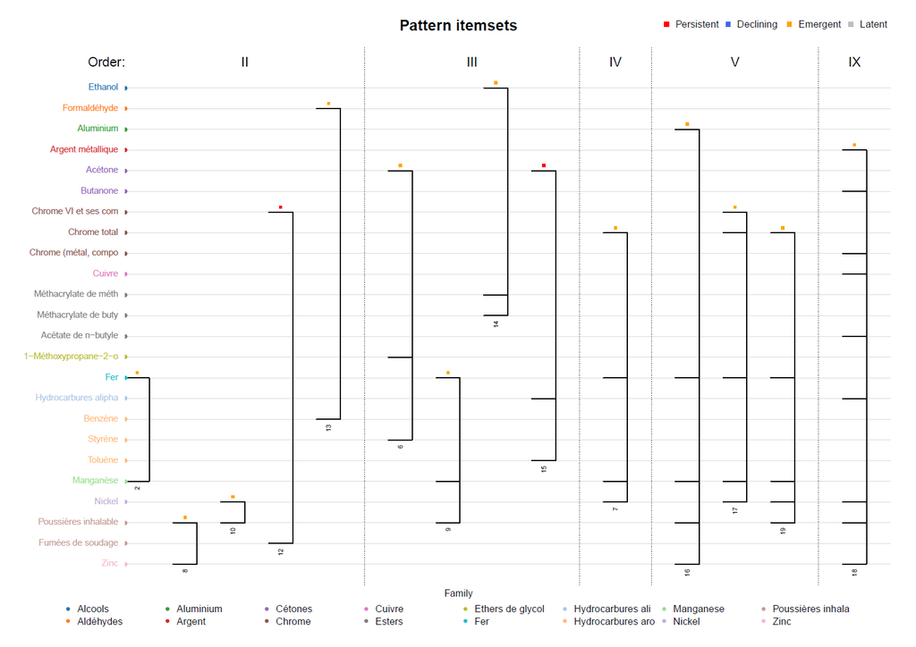

Fig. 4.a: Itemsets corresponding to the mined patterns (except those of length 1.

**Note that too many values for the displayed category or too long names prevent the legend from being displayed entirely, hence the use of the *c.cutoff* parameter to reduce the size of these values. Likewise, the *n.cutoff* allow to shorten the names of long substances.**

Saving pattern characteristics in a CSV file…

```r
save_characteristics(sa_object, p_chart,
                     file = paste0(directory, "pattern_itemsets.csv"),
                     row.names = FALSE)

p_chart
```

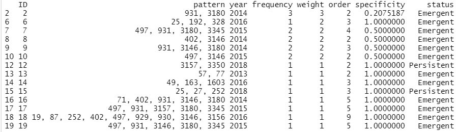

See that only patterns with a length greater than 1 are plotted on this chart. The argument `length_one` allows to plot all patterns.

```r
p_chart <- itemset_chart(sa_object, sa_object["patterns"],
                         n.cutoff = 20,
                         c.cutoff = 16,
                         length_one = TRUE,
                         path = directory,
                         name = "all_pattern_itemsets.pdf",
                         title = "All pattern itemsets")
```

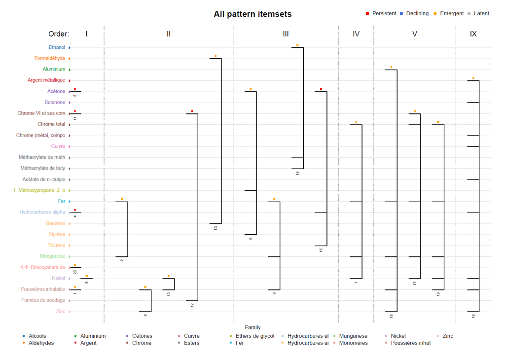

Fig. 4.b: Itemsets corresponding to the mined patterns.

### 3.1.2. Spectrum

Creation of the pattern spectrum…

```r
spectrum <- spectrum_chart(sa_object, sa_object["patterns"],
                           path = directory,
                           name = "spectrum_of_patterns.pdf",
                           title = "Spectrum of patterns")
```

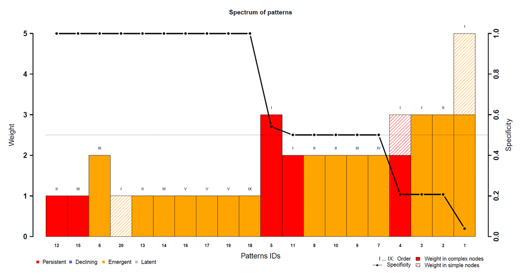

Fig. 5: Spectrum of patterns.

Saving pattern characteristics in a CSV file…

```r
save_characteristics(sa_object, spectrum,
                     file = paste0(directory, "spectrum_of_patterns.csv"),
                     row.names = FALSE)
```

Patterns presented in this spectrum are the ones already saved before as “sao.patterns.csv” in section 1.4.

### 3.1.3. Spectrosome

Creation of the spectrosome of the patterns…

```r
spectrosome <- spectrosome_chart(sa_object, sa_object["patterns"],
                                 path = directory,
                                 name = "spectrosome_of_patterns.png",
                                 title = "Network of patterns")
```

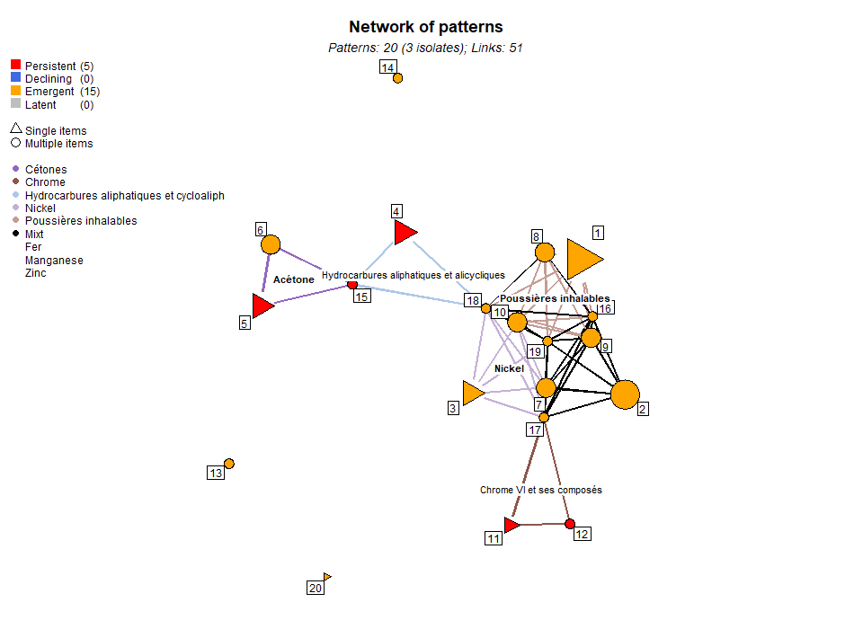

Fig. 6: Spectrosome of the patterns.

Saving vertex characteristics in a CSV file…

```r
save_characteristics(sa_object, spectrosome[["vertices"]],
                     file = paste0(directory, "spectrosome_of_patterns-vertices.csv"),
                     row.names = FALSE)
# Here they are again the same patterns
```

Saving edges characteristics as well…

```r
write.csv2(spectrosome[["edges"]],
           file = paste0(directory, "spectrosome_of_patterns-edges.csv"),
           row.names = FALSE)

spectrosome[["edges"]]
```

| ID | endpoint.1 | endpoint.2 | items | weight | year |
| --- | --- | --- | --- | --- | --- |
| 1 | 1 | 8 | 3146 | 1 | 2014 |
| 2 | 1 | 9 | 3146 | 1 | 2014 |
| 3 | 1 | 10 | 3146 | 1 | 2015 |
| 4 | 1 | 16 | 3146 | 1 | 2014 |
| 5 | 1 | 18 | 3146 | 1 | 2016 |
| 6 | 1 | 19 | 3146 | 1 | 2015 |
| 7 | 2 | 7 | 931/3180 | 2 | 2015 |
| 8 | 2 | 9 | 931/3180 | 2 | 2014 |
| 9 | 2 | 16 | 931/3180 | 2 | 2014 |
| 10 | 2 | 17 | 931/3180 | 2 | 2015 |

[output cut: 44 more lines]

```r
# Print the network density
cat("Network density:", network_density(sa_object, spectrosome[["edges"]]))
```

```
Network density: 0.2684211
```

## 3.2. Extraction of a cluster of patterns

Extraction of the pattern cluster relating to the item *3146*…

```r
item <- 3146
cluster <- cluster_chart(sa_object, sa_object["patterns"], item,
                         path = directory,
                         name = paste0("pattern_cluster_of_", item, ".png"),
                         title = paste("Network cluster of", item))
```

**Note that no graphic is created and *cluster* is *NULL* if none or only one pattern contains the desired substance (which is here the substance having the code *3146*).**

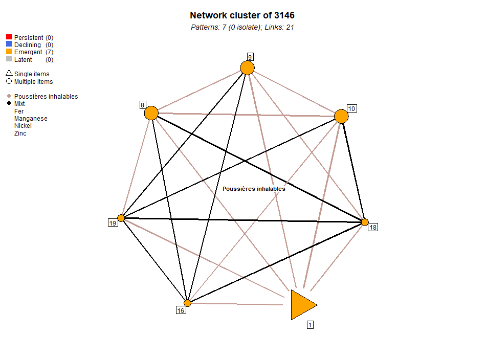

Fig. 7: Pattern cluster of 3146.

Saving vertex characteristics in CSV format…

```r
save_characteristics(sa_object, cluster[["vertices"]],
                     file = paste0(directory, "pattern_cluster_of_", item, "-vertices.csv"),
                     row.names = FALSE)

cluster[["vertices"]]
```

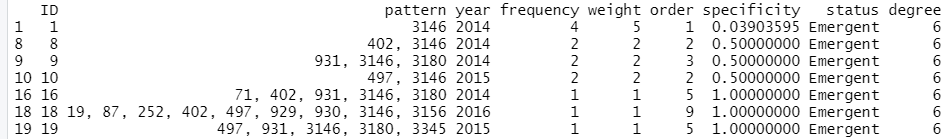

Saving edges characteristics as well…

```r
write.csv2(cluster[["edges"]],
           file = paste0(directory, "pattern_cluster_of_", item, "-edges.csv"),
           row.names = FALSE)

cluster[["edges"]]
```

|  | ID | endpoint.1 | endpoint.2 | items | weight | year |
| --- | --- | --- | --- | --- | --- | --- |
| 1 | 1 | 1 | 8 | 3146 | 1 | 2014 |
| 2 | 2 | 1 | 9 | 3146 | 1 | 2014 |
| 3 | 3 | 1 | 10 | 3146 | 1 | 2015 |
| 4 | 4 | 1 | 16 | 3146 | 1 | 2014 |
| 5 | 5 | 1 | 18 | 3146 | 1 | 2016 |
| 6 | 6 | 1 | 19 | 3146 | 1 | 2015 |
| 28 | 7 | 8 | 9 | 3146 | 1 | 2014 |
| 29 | 8 | 8 | 10 | 3146 | 1 | 2015 |
| 30 | 9 | 8 | 16 | 402/3146 | 2 | 2014 |
| 31 | 10 | 8 | 18 | 402/3146 | 2 | 2016 |

[output cut: 11 more lines]

# 4. Filters on nodes and patterns

```r
directory <- "./output/spec_filter/"
dir.create(directory)
```

## 4.1. Example of pattern weight filter

Selection of patterns with filter according to weight…

```r
# For example: patterns with at least a weight of 3
min_weight <- 3
patterns <- get_patterns(sa_object, sa_object["patterns"],
                         element = "weight",
                         value = min_weight,
                         condition = ">=")

patterns
```

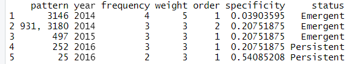

Associated spectrum…

```r
spectrum <- spectrum_chart(sa_object, patterns,
                           path = directory,
                           name = paste0("spectrum_of_patterns-w", min_weight, ".pdf"),
                           title = paste("Spectrum with weight filter"))
```

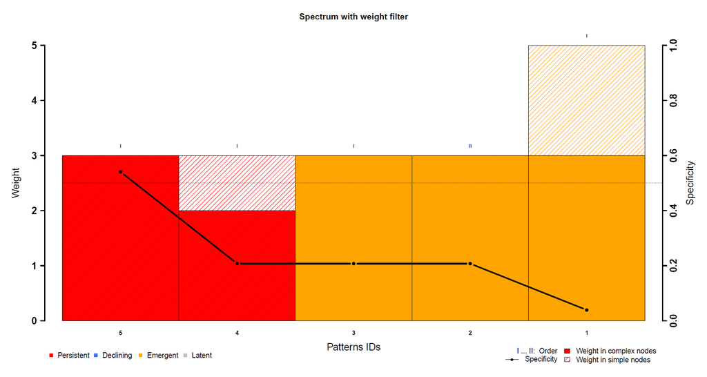

Fig. 8: Spectrum of patterns with weigh filter.

Associated spectrosome…

```r
spectrosome <- spectrosome_chart(sa_object, patterns,
                                 path = directory,
                                 name = paste0("spectrosome_of_patterns-w", min_weight, ".png"),
                                 title = "Spectrosome with weight filter")
```

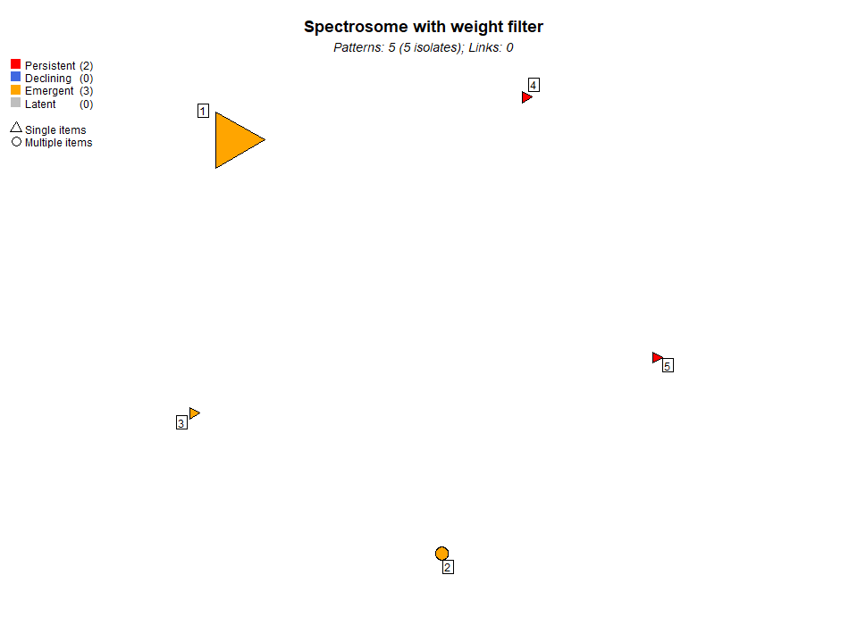

Fig. 9: Spectrosome of the patterns with weight filter.

## 4.2. Example of pattern status filter

Selection of patterns with filter according to status…

```r
# For example: patterns with a status "Persistent"
status <- "Persistent"
patterns <- get_patterns(sa_object, sa_object["patterns"],
                         element = "status",
                         value = status,
                         condition = "EQ")

patterns
```

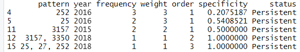

**Note that after applying a filter, the patterns keep their line identifiers from the whole set of patterns.**

Associated spectrum…

```r
spectrum <- spectrum_chart(sa_object, patterns,
                           path = directory,
                           name = paste0("spectrum_of_patterns-", status, ".pdf"),
                           title = paste("Spectrum with status filter"))
```

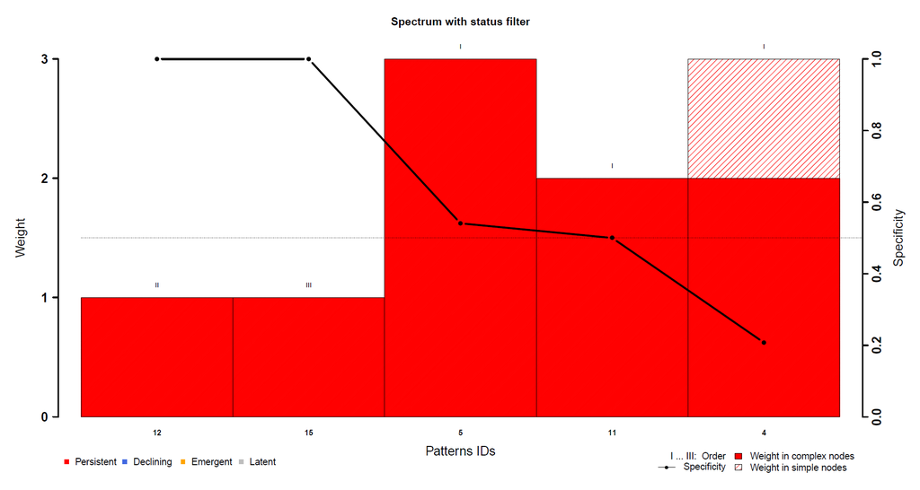

Fig. 10: Spectrum of patterns with stauts filter.

Associated spectrosome…

```r
spectrosome <- spectrosome_chart(sa_object, patterns,
                                 path = directory,
                                 name = paste0("spectrosome_of_patterns-", status, ".png"),
                                 title = "Spectrosome with status filter")
```

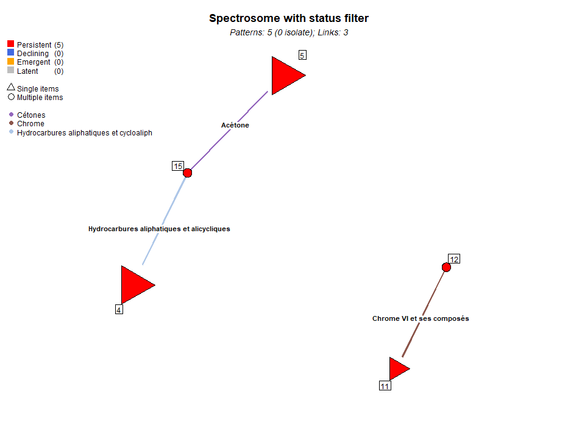

Fig. 11: Spectrosome of the patterns with status filter.

```r
# Print the network density
cat("Network density:", network_density(sa_object, spectrosome[["edges"]]))
```

```
Network density: 0.3
```

## 4.3. Specific case of category filters

### 4.3.1. Patterns related to one specific family

```r
directory <- "./output/spec_family/"
dir.create(directory)
```

Substances in the family *Chrome*…

```r
items[items$family == "Chrome", ]
```

|  | item | name | family |
| --- | --- | --- | --- |
| 21 | 3156 | Chrome (métal, composés de chrome inorganiques (II) et composés de chrome inorganiques (insolubles) (III)) | Chrome |
| 22 | 3157 | Chrome VI et ses composés | Chrome |
| 24 | 3345 | Chrome total | Chrome |

Selection of patterns which contain any substance in the family *Chrome*…

```r
patterns <- get_patterns(sa_object, sa_object["patterns"],
                         element = "family",
                         value = "Chrome",
                         condition = "items")
patterns
```

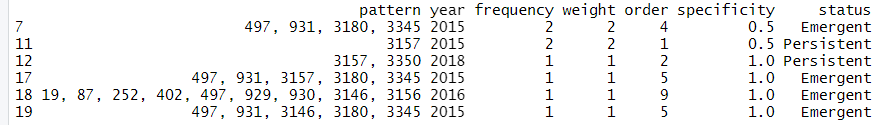

Spectrosome related to this selection…

```r
name <- "spectrosome_of_patterns-Chrome-vertices"
spectrosome <- spectrosome_chart(sa_object, patterns,
                                 path = directory,
                                 name = name,
                                 title = "Spectrosome of category Chrome")
```

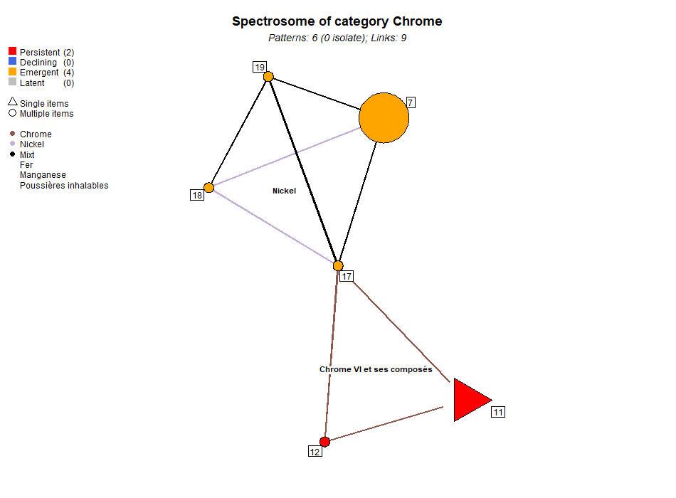

Fig. 12: Spectrosome of the patterns containing at least one substance related to the family named “Chrome”.

Saving vertex characteristics in a CSV file…

```r
save_characteristics(sa_object, spectrosome[["vertices"]],
                     file = paste0(directory, name, "-vertices.csv"),
                     row.names = FALSE)

spectrosome[["vertices"]]
```

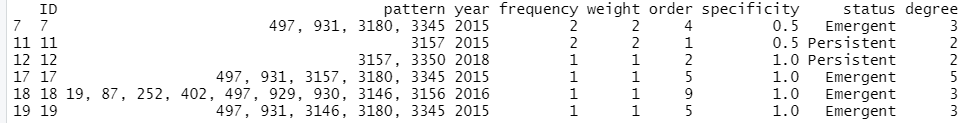

And saving edges characteristics in CSV format…

```r
write.csv2(spectrosome[["edges"]],
           file = paste0(directory, name, "-edges.csv"),
           row.names = FALSE)

spectrosome[["edges"]]
```

|  | ID | endpoint.1 | endpoint.2 | items | weight | year |
| --- | --- | --- | --- | --- | --- | --- |
| 25 | 1 | 7 | 17 | 497/931/3180/3345 | 4 | 2015 |
| 26 | 2 | 7 | 18 | 497 | 1 | 2016 |
| 27 | 3 | 7 | 19 | 497/931/3180/3345 | 4 | 2015 |
| 42 | 4 | 11 | 12 | 3157 | 1 | 2018 |
| 43 | 5 | 11 | 17 | 3157 | 1 | 2015 |
| 44 | 6 | 12 | 17 | 3157 | 1 | 2018 |
| 49 | 7 | 17 | 18 | 497 | 1 | 2016 |
| 50 | 8 | 17 | 19 | 497/931/3180/3345 | 4 | 2015 |
| 51 | 9 | 18 | 19 | 497/3146 | 2 | 2016 |

### 4.3.2. Patterns generating links corresponding to one specific family

Substances in the family *Chrome* (the same as in the previous section)…

```r
items[items$family == "Chrome", ]
```

|  | item | name | family |
| --- | --- | --- | --- |
| 21 | 3156 | Chrome (métal, composés de chrome inorganiques (II) et composés de chrome inorganiques (insolubles) (III)) | Chrome |
| 22 | 3157 | Chrome VI et ses composés | Chrome |
| 24 | 3345 | Chrome total | Chrome |

Selection of patterns which generate links in which any substance belongs to the family *Chrome*…

```r
patterns <- get_patterns(sa_object, sa_object["patterns"],
                         element = "family",
                         value = "Chrome",
                         condition = "links")
patterns
```

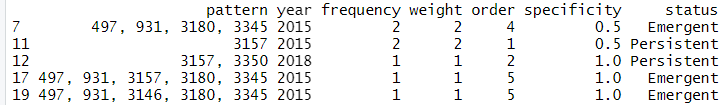

**Note that the difference between this section and the previous one is that there is less patterns because some of the previous ones are not linked with other by a substance in the sought category (although they are effectively linked by other substances).**

Spectrosome related to this selection…

```r
name <- "spectrosome_of_patterns-Chrome-edges"
spectrosome <- spectrosome_chart(sa_object, patterns,
                                 path = directory,
                                 name = paste0(name, ".png"),
                                 title = paste("Spectrosome of category Chrome"))
```

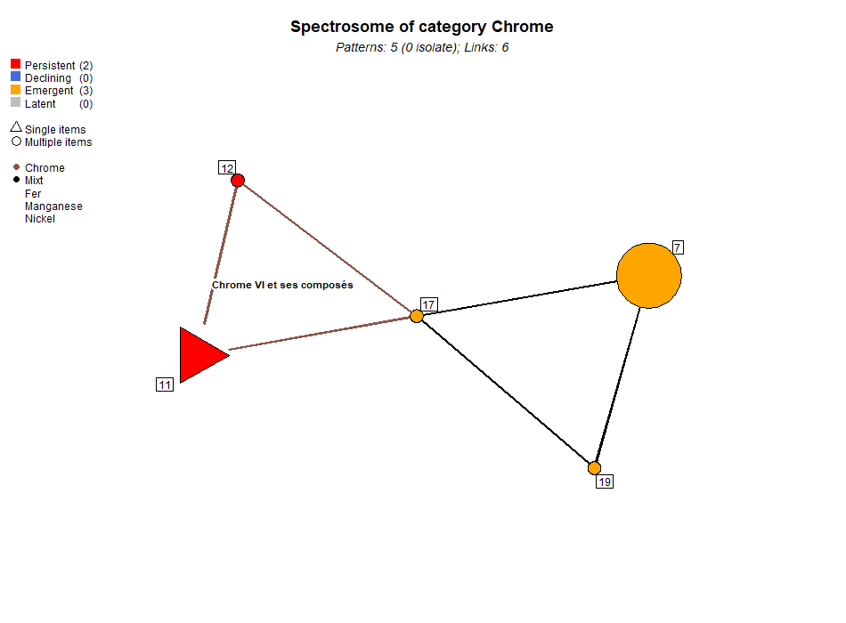

Fig. 13: Spectrosome of the patterns generating at least one link related to the family named “Chrome”.

Saving vertex characteristics in a CSV file…

```r
save_characteristics(sa_object, spectrosome[["vertices"]],
                     file = paste0(directory, name, "-vertices.csv"),
                     row.names = FALSE)

spectrosome[["vertices"]]
```

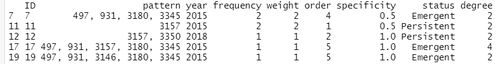

And saving edges characteristics in a CSV file…

```r
write.csv2(spectrosome[["edges"]],
           file = paste0(directory, name, "-edges.csv"),
           row.names = FALSE)

spectrosome[["edges"]]
```

|  | ID | endpoint.1 | endpoint.2 | items | weight | year |
| --- | --- | --- | --- | --- | --- | --- |
| 25 | 1 | 7 | 17 | 497/931/3180/3345 | 4 | 2015 |
| 27 | 2 | 7 | 19 | 497/931/3180/3345 | 4 | 2015 |
| 42 | 3 | 11 | 12 | 3157 | 1 | 2018 |
| 43 | 4 | 11 | 17 | 3157 | 1 | 2015 |
| 44 | 5 | 12 | 17 | 3157 | 1 | 2018 |
| 50 | 6 | 17 | 19 | 497/931/3180/3345 | 4 | 2015 |

## 4.4. Complex nodes and patterns

Let’s take a look at another example which has a way more patterns (the creation of the concerning spectral analyzer object is not shown).

```r
directory <- "./output/another_sa_object/"
dir.create(directory)

spectrosome_c <- spectrosome_chart(another_sa_object, another_sa_object["patterns"],
                                   vertex_size = "grouped", size_range = c(0.5, 1.5),
                                   displayisolates = FALSE, displaylabels = FALSE,
                                   path = directory, name = "without_isolates")
```

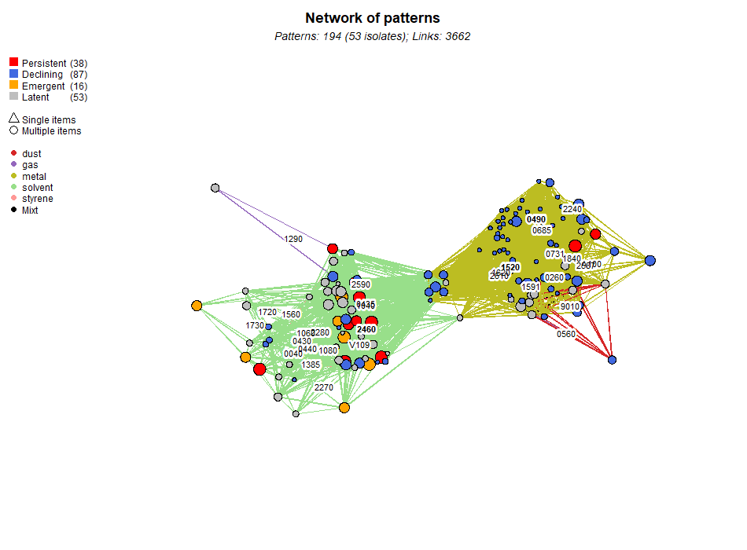

Fig. 14: Spectrosome of patterns from another spectral analyzer, without displaying the isolates or the labels

To focus on the patterns that make the junction between two or more families of substances (i.e. two values of one category), use the following…

```r
patterns <- get_complexes(another_sa_object, another_sa_object["patterns"],
                          category = "family", condition = "vertices")

spectrosome_c <- spectrosome_chart(another_sa_object, patterns,
                                   vertex_col = "categories",
                                   title = "Complexe patterns",
                                   path = directory, name = "complexe_patterns")
```

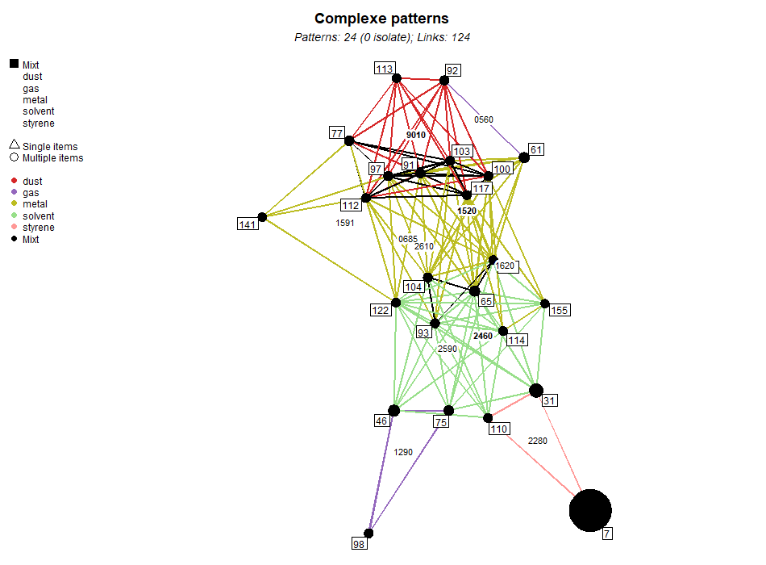

Fig. 15: Spectrosome of patterns which are associated with more than one family of substances.